# Vaccination and voting patterns in the United States: analysis of COVID-19 and flu surveys from 2010 to 2022

Minttu Rönn

2023-Mar-02

## Part 1

### SUPPLEMENTAL FIGURE S1 A

Comparison of correlation coefficient across state-level COVID-19 vaccination estimates by month. We have omitted Washington D.C. as an outlier. Pearson correlation coefficient (R) shown by month in panels A,C,D, and as a bar plot in panel B.

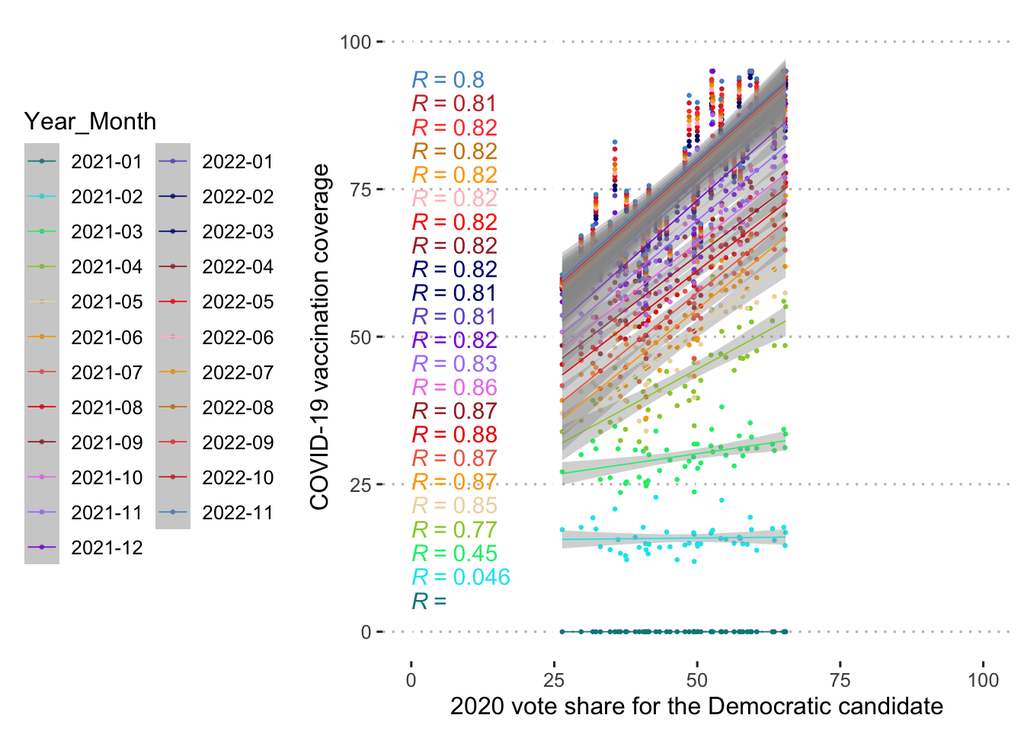

### SUPPLEMENTAL FIGURE S1 B

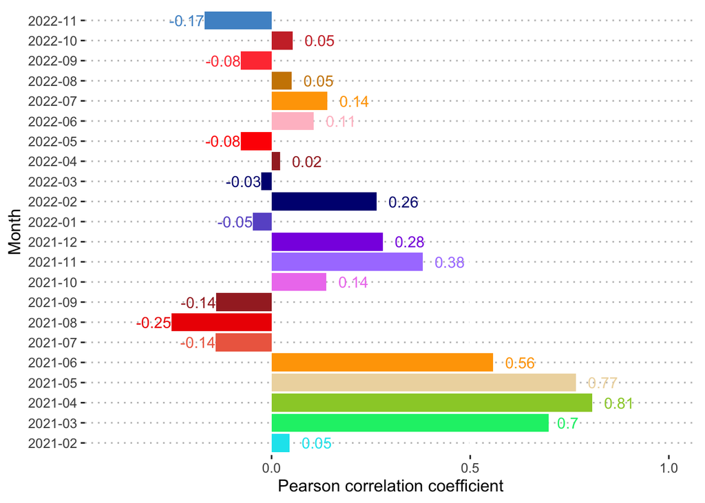

### SUPPLEMENTAL FIGURE S1 C

Comparison of correlation coefficient across state-level COVID-19 vaccination estimates by month. We have omitted Washington D.C. as an outlier. Pearson correlation coefficient (R) shown by month in panels A,C,D, and as a bar plot in panel B.

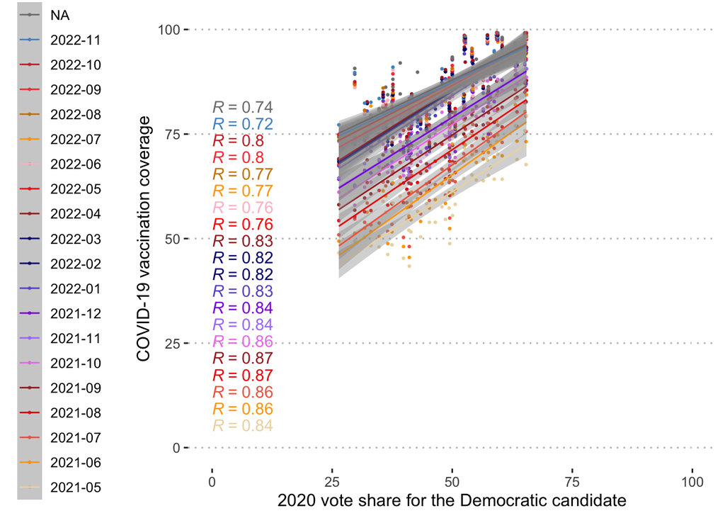

- Obtain linear predictions by month for CDC surveillance data on COVID-19 vaccination

```
## [1] "CDC linear regression by month"
```

```
## Call: lmList(formula = est ~ vote_perc | Year_Month, data = fits_cdc)
## Coefficients:
##         (Intercept)  vote_perc
## 2021-01     0.00000 0.00000000
## 2021-02    15.37410 0.01022975
## 2021-03    23.06154 0.14220749
## 2021-04    18.08692 0.52797035
## 2021-05    14.18807 0.74302507
## 2021-06    15.18415 0.78998952
## 2021-07    18.45237 0.77933354
## 2021-08    23.78716 0.74744731
## 2021-09    26.93554 0.73645271
## 2021-10    28.12858 0.75588817
## 2021-11    29.02353 0.81323388
## 2021-12    30.01635 0.86144055
## 2022-01    32.88226 0.85422991
## 2022-02    33.33506 0.86352243
## 2022-03    33.83155 0.86154114
## 2022-04    34.23549 0.86246512
## 2022-05    34.74122 0.85982879
## 2022-06    34.91616 0.86379279
## 2022-07    35.23545 0.86624002
## 2022-08    35.56826 0.86743902
## 2022-09    36.10882 0.85992116
## 2022-10    36.52672 0.86201995
## 2022-11    37.28666 0.85568911
##
## Degrees of freedom: 1150 total; 1104 residual
## Residual standard error: 5.457948
```

- Obtain linear predictions by month for NIS-ACM data on COVID-19 vaccination

```
## [1] "ACM linear regression by month"
```

```
## Call: lmList(formula = est ~ vote_perc | Year_Month, data = fits_acm)
## Coefficients:
##         (Intercept) vote_perc
## 2021-05    24.37323 0.7362913
## 2021-06    24.35642 0.8184988
## 2021-07    26.57460 0.8208853
## 2021-08    32.52826 0.7744296
## 2021-09    36.99269 0.7558020
## 2021-10    39.90069 0.7472894
## 2021-11    43.39027 0.7123253
## 2021-12    43.16916 0.7162485
## 2022-01    47.13533 0.7424535
## 2022-02    48.50980 0.7344762
## 2022-03    48.91790 0.7326292
## 2022-04    49.55444 0.7258245
## 2022-05    59.08928 0.5479233
## 2022-06    57.66459 0.5765367
## 2022-07    58.60594 0.5614960
## 2022-08    59.69009 0.5468999
## 2022-09    55.32828 0.6254382
## 2022-10    57.97541 0.5880514
## 2022-11    60.15140 0.5450693
##
## Degrees of freedom: 950 total; 912 residual
## Residual standard error: 4.966473
```

### SUPPLEMENTAL FIGURE S2

Absolute monthly difference in COVID-19 vaccination coverage, compared at state-level to previous month. Shading represents 2020 vote share for the Democratic candidate. Data: CDC Surveillance

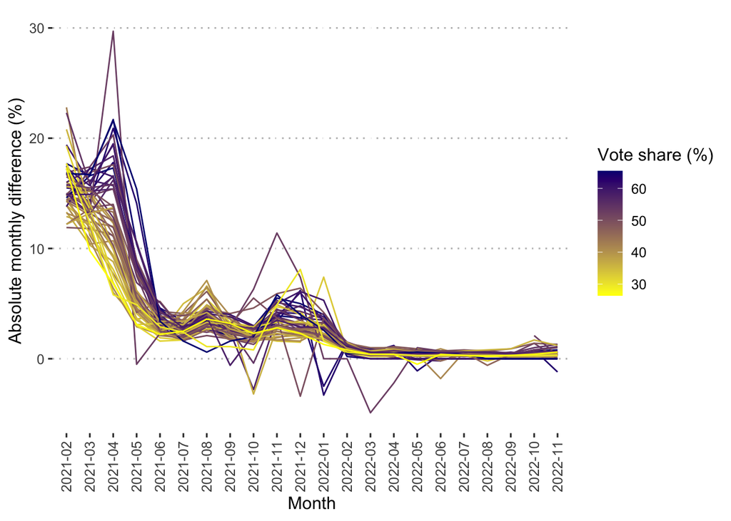

Footnote The data are presented as they were reported, and no data cleaning were done to adjust for potential reporting changes and/or errors; e.g. reductions in population level vaccination coverage observed for some states.